In this problem, you will develop a model to predict whether a given car gets high or low gas mileage based on the Auto data set.

1. Create a binary variable, `mpg01`, that contains a 1 if mpg contains a value above its median, and a 0 if `mpg` contains a value below its median. You can compute the median using the `median()` function.

```r
Auto$mpg01<-as.integer(as.logical(Auto$mpg>median(Auto$mpg)))
```

2. Explore the data graphically in order to investigate the association between `mpg01` and the other features. Which of the other features seem most likely to be useful in predicting `mpg01`? Scatterplots and boxplots may be useful tools to answer this question. Describe your findings.

`Horsepower`, `weight`, and `acceleration` will likely be the most useful in predicting `mpg01`. There is a distinction between 0 and 1 values that a log transform can be applied to. There needs to be a distinction between 0 and 1 values for there to be discrimination within the dependent varaible. This is visible in the scatterplot for `horsepower`, `weight`, and `acceleration`. The other variables have too much or complete overlap in 1 and 0 values.

`Horsepower` and `weight` are highly correlated (0.86), therefore it may not be appropriate to use both in the same model (confounding variables). `Weight` has a higher corrleation with `mpg` and `mpg01` than `horsepower`, so will be used instead.

```r
names(Auto)
```

```
##  [1] "mpg"          "cylinders"    "displacement" "horsepower"
##  [5] "weight"       "acceleration" "year"         "origin"
##  [9] "name"         "mpg01"
```

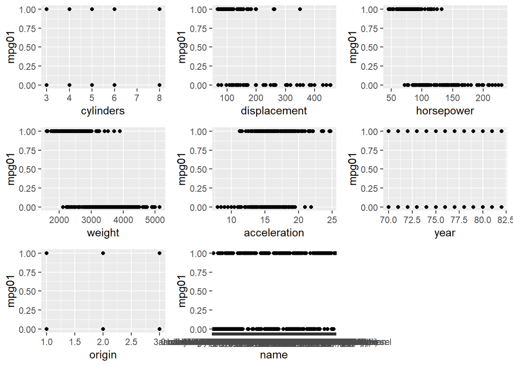

```r
cyl<-ggplot(Auto, aes(y=mpg01,x=cylinders)) + geom_point()
displ<-ggplot(Auto, aes(y=mpg01,x=displacement)) + geom_point()
horse<-ggplot(Auto, aes(y=mpg01,x=horsepower)) + geom_point()
weight<-ggplot(Auto, aes(y=mpg01,x=weight)) + geom_point()
acc<-ggplot(Auto, aes(y=mpg01,x=acceleration)) + geom_point()
yr<-ggplot(Auto, aes(y=mpg01,x=year)) + geom_point()
origin<-ggplot(Auto, aes(y=mpg01,x=origin)) + geom_point()
name<-ggplot(Auto, aes(y=mpg01,x=name)) + geom_point()

grid.arrange(cyl, displ, horse,weight,acc,yr,origin,name, ncol = 3, nrow = 3)
```

```r
# Combining correlogram with the significance test
# http://www.sthda.com/english/wiki/visualize-correlation-matrix-using-correlogram
cor_mtest <- function(mat, ...) {
    mat <- as.matrix(mat)
    n <- ncol(mat)
    pval<- matrix(NA, n, n)
    diag(pval) <- 0
    for (i in 1:(n - 1)) {
        for (j in (i + 1):n) {
            tmp <- cor.test(mat[, i], mat[, j], ...)
            pval[i, j] <- pval[j, i] <- tmp$p.value
        }
    }
  colnames(pval) <- rownames(pval) <- colnames(mat)
  pval
}
# matrix of the p-value of the correlation
pval <- cor_mtest(Auto[,!names(Auto) %in% c("name")])
head(pval[, 1:5])
```

```
##                        mpg     cylinders  displacement    horsepower
## mpg           0.000000e+00  1.311384e-80  1.660642e-90  7.031989e-81
## cylinders     1.311384e-80  0.000000e+00 1.298636e-200 4.633884e-107
## displacement  1.660642e-90 1.298636e-200  0.000000e+00 1.510889e-140
## horsepower    7.031989e-81 4.633884e-107 1.510889e-140  0.000000e+00
## weight       6.015296e-102 9.290616e-141 3.489084e-175 1.364347e-118
## acceleration  1.778576e-18  1.009001e-26  1.508540e-31  1.581886e-56
##                     weight
## mpg          6.015296e-102
## cylinders    9.290616e-141
## displacement 3.489084e-175
## horsepower   1.364347e-118
## weight        0.000000e+00
## acceleration  6.565616e-18
```

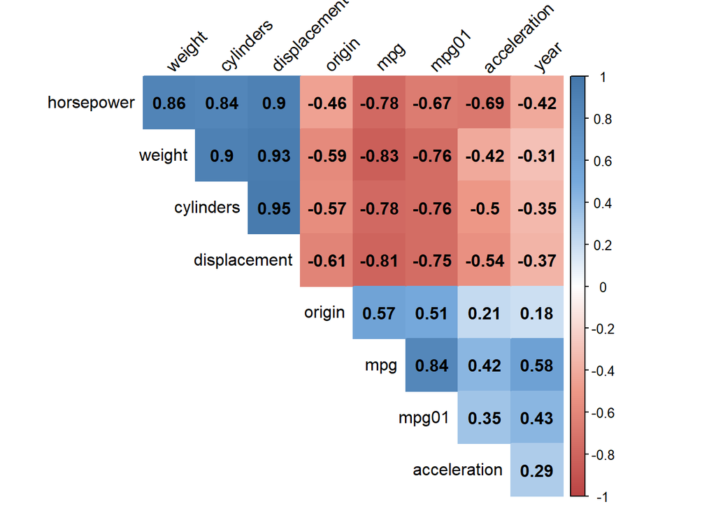

```r
col <- colorRampPalette(c("#BB4444", "#EE9988", "#FFFFFF", "#77AADD", "#4477AA"))
AutoCorr<-cor(Auto[,!names(Auto) %in% c("name")])

corrplot(AutoCorr, method="color", col=col(200),
         type="upper", order="hclust",
         addCoef.col = "black", # Add coefficient of correlation
         tl.col="black", tl.srt=45, #Text label color and rotation
         # Combine with significance
         # Add significance level to the correlogram
         # Correlations with p-value > 0.01 (sig.level) are considered insignificant (insig) and left "blank"; otherwise
         # the color is associated with the neg or pos correlation of two variables
         p.mat = pval, sig.level = 0.01, insig = "blank",
         # hide correlation coefficient on the principal diagonal
         diag=FALSE
         )
```

```r
# keep mpg, mpg01, weight, and acceleration
ColKeep <- names(Auto) %in% c("mpg","mpg01", "weight","acceleration")
Auto_sub <- Auto[ColKeep]
```

3. Split the data into a training set and a test set.

```r
rp <- resample_partition(Auto_sub, c(train = 0.7, test = 0.3))
training_set <- as_tibble(rp$train)
testing_set <- as_tibble(rp$test)
```

4. Perform LDA on the training data in order to predict `mpg01` using the variables that seemed most associated with `mpg01` in (b). What is the test error of the model obtained?

```r
lda_fit <- lda(as.factor(mpg01) ~ weight + acceleration, data = training_set)
lda_fit
```

```
## Call:
## lda(as.factor(mpg01) ~ weight + acceleration, data = training_set)
##
## Prior probabilities of groups:
##         0         1
## 0.5072993 0.4927007
##
## Group means:
##     weight acceleration
## 0 3604.381     14.61655
## 1 2251.311     16.37704
##
## Coefficients of linear discriminants:
##                       LD1
## weight       -0.001902842
## acceleration -0.009499313
```

```r
#train error
TrainPred<-predict(lda_fit, training_set)
PredTable <- table(TrainPred$class, training_set$mpg01)
# 1 - (total correct / total)
TrainError<-(1-(sum(diag(PredTable))/sum(PredTable)))
TrainError # 0.1313869
```

```
## [1] 0.09489051
```

```r
#test error
TestPred<-predict(lda_fit, testing_set)
PredTable <- table(TestPred$class, testing_set$mpg01)
# 1 - (total correct / total)
TestError<-(1-(sum(diag(PredTable))/sum(PredTable)))
TestError # 0.1016949
```

```
## [1] 0.1694915
```

5. Perform QDA on the training data in order to predict `mpg01` using the variables that seemed most associated with `mpg01` in (b). What is the test error of the model obtained?

```r
qda_fit <- qda(mpg01 ~ weight + acceleration, data = training_set)
qda_fit
```

```
## Call:
## qda(mpg01 ~ weight + acceleration, data = training_set)
##
## Prior probabilities of groups:
##         0         1
## 0.5072993 0.4927007
##
## Group means:
##     weight acceleration
## 0 3604.381     14.61655
## 1 2251.311     16.37704
```

```r
#train error
TrainPred<-predict(qda_fit, training_set)
PredTable <- table(TrainPred$class, training_set$mpg01)
# 1 - (total correct / total)
TrainError<-(1-(sum(diag(PredTable))/sum(PredTable)))
TrainError # 0.1277372
```

```
## [1] 0.08029197
```

```r
#test error
TestPred<-predict(qda_fit, testing_set)
PredTable <- table(TestPred$class, testing_set$mpg01)
# 1 - (total correct / total)
TestError<-(1-(sum(diag(PredTable))/sum(PredTable)))
TestError # 0.1016949
```

```
## [1] 0.1864407
```

6. Perform logistic regression on the training data in order to predict `mpg01` using the variables that seemed most associated with `mpg01` in (b). What is the test error of the model obtained?

```r
glm_fit <- glm(mpg01 ~ weight + acceleration, data = training_set, family=binomial)
glm_fit
```

```
##
## Call:  glm(formula = mpg01 ~ weight + acceleration, family = binomial,
##     data = training_set)
##
## Coefficients:
##  (Intercept)        weight  acceleration
##    12.822632     -0.005535      0.149900
##
## Degrees of Freedom: 273 Total (i.e. Null);  271 Residual
## Null Deviance:       379.8
## Residual Deviance: 121   AIC: 127
```

```r
#train error
#training_set %>% add_predictions(glm_fit) %>% mutate(prob = exp(pred)/ (1 + exp(pred)))
TrainPred <- training_set %>%
    add_predictions(glm_fit) %>%
    mutate(prob = exp(pred)/ (1 + exp(pred)), EstMpg = ifelse(prob > 0.5, 1, 0))
PredTable<-TrainPred %>% count(mpg01, EstMpg) %>% spread(mpg01, n)
PredTable2<-cbind(PredTable$`0`,PredTable$`1`)
TrainError<-(1-(sum(diag(PredTable2))/sum(PredTable2)))
TrainError # 0.07627119
```

```
## [1] 0.08029197
```

```r
#test error
TestPred <- testing_set %>%
    add_predictions(glm_fit) %>%
    mutate(prob = exp(pred)/ (1 + exp(pred)), EstMpg = ifelse(prob > 0.5, 1, 0))
PredTable<-TestPred %>% count(mpg01, EstMpg) %>% spread(mpg01, n)
PredTable2<-cbind(PredTable$`0`,PredTable$`1`)
TestError<-(1-(sum(diag(PredTable2))/sum(PredTable2)))
TestError # 0.07627119
```

```
## [1] 0.2033898
```

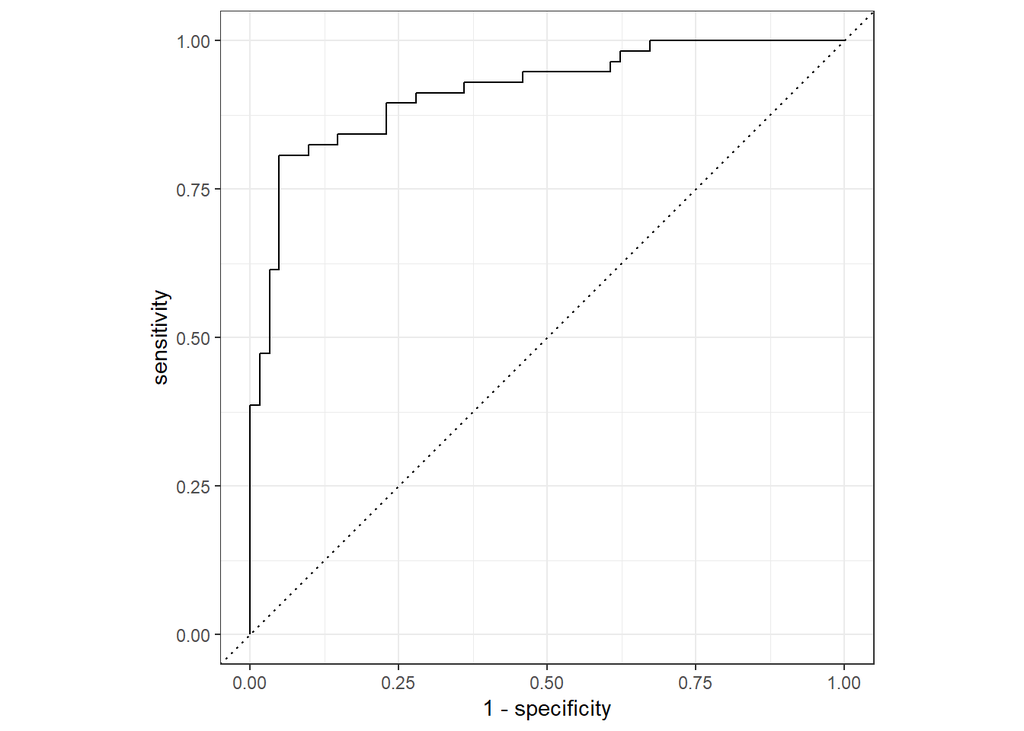

```r
autoplot(roc_curve(TestPred, as.factor(mpg01), prob))
```

```r
roc_auc(TestPred, as.factor(mpg01), prob)
```

```
## # A tibble: 1 x 3
##   .metric .estimator .estimate
##   <chr>   <chr>          <dbl>
## 1 roc_auc binary         0.915
```

7. Perform KNN on the training data, with several values of $K$, in order to predict `mpg01`. Use only the variables that seemed most associated with `mpg01` in (b). What test errors do you obtain? Which value of $K$ seems to perform the best on this data set?

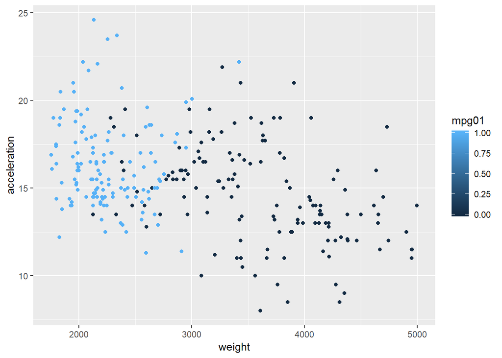

```r
ggplot(training_set) + geom_point(aes(weight, acceleration, color = mpg01))
```

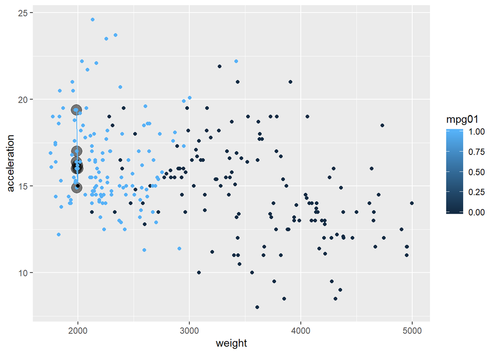

```r
k = 7
point = c(2000, 15)
knn_neighor <- training_set %>%
mutate(dist = sqrt((weight - point[1])^2 + (acceleration - point[2])^2)) %>%
filter(row_number(dist) <= k)
ggplot(training_set) +
  geom_point(data = knn_neighor, aes(weight, acceleration), alpha = 0.5, size = 5) +
  geom_segment(data = knn_neighor, aes(x = weight, y = acceleration, xend = point[1], yend = point[2], color = mpg01)) +
  geom_point(aes(weight, acceleration, color = mpg01)) +
  annotate("point", x = point[1], y = point[2])
```

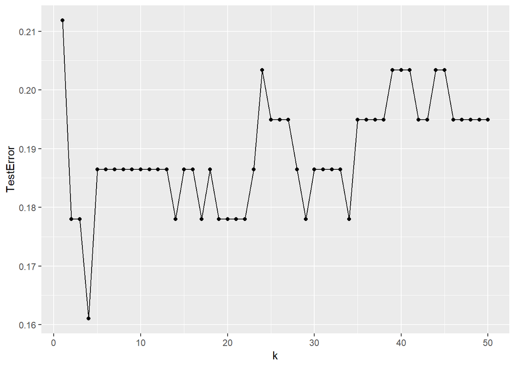

```r
Ks=c(1:50)
TestError_Ks<-data.frame()
for (k in Ks) {
  TestPred<-testing_set %>% mutate(EstMpg = class::knn(training_set %>% select(weight, acceleration), testing_set %>% select(weight, acceleration), training_set %>% pull(mpg01), k=k))

  TestPred$EstMpg
  TestPred$mpg01

  PredTable<-TestPred %>% count(mpg01, EstMpg) %>% spread(mpg01, n)
  PredTable2<-cbind(PredTable$`0`,PredTable$`1`)
  TestError<-(1-(sum(diag(PredTable2))/sum(PredTable2)))
  fillerDF<-data.frame(k,TestError)

  TestError_Ks<-rbind(TestError_Ks,fillerDF)
}

ggplot(aes(x = k, y = TestError), data=TestError_Ks) +
  geom_point() +
  geom_line()
```